# Survival Analysis using Kaplan-Meier method

## Load required packages

```r
knitr::opts_chunk$set(echo = TRUE)
knitr::opts_chunk$set(cache = TRUE)
#install.packages(c("survival"))
library(survival)
library(survminer)
```

## Data

```r
a_data <- read.csv('data/necessary_fields.csv', stringsAsFactors = TRUE)
str(a_data)
```

```
## 'data.frame':    2111 obs. of  6 variables:
##  $ host_type        : Factor w/ 3 levels "deb","git","pypi": 1 1 1 1 1 1 1 1 1 1 ...
##  $ censored         : int  1 0 1 1 1 1 1 1 1 0 ...
##  $ duration_months  : int  90 130 36 92 122 60 101 106 98 44 ...
##  $ high_rev_freq    : Factor w/ 2 levels "False","True": 1 1 1 1 1 1 1 1 1 1 ...
##  $ multi_repo       : Factor w/ 2 levels "False","True": 1 1 1 1 2 1 1 1 1 1 ...
##  $ high_author_count: Factor w/ 2 levels "False","True": 1 1 1 1 1 1 1 1 1 1 ...
```

```r
a_data$censored = as.logical(a_data$censored)
a_data$death_observed = as.logical(!a_data$censored)
a_data$high_rev_freq = as.logical(a_data$high_rev_freq)
a_data$high_author_count = as.logical(a_data$high_author_count)
a_data$multi_repo = as.logical(a_data$multi_repo)
str(a_data)
```

```
## 'data.frame':    2111 obs. of  7 variables:
##  $ host_type        : Factor w/ 3 levels "deb","git","pypi": 1 1 1 1 1 1 1 1 1 1 ...
##  $ censored         : logi  TRUE FALSE TRUE TRUE TRUE TRUE ...
##  $ duration_months  : int  90 130 36 92 122 60 101 106 98 44 ...
##  $ high_rev_freq    : logi  FALSE FALSE FALSE FALSE FALSE FALSE ...
##  $ multi_repo       : logi  FALSE FALSE FALSE FALSE TRUE FALSE ...
##  $ high_author_count: logi  FALSE FALSE FALSE FALSE FALSE FALSE ...
##  $ death_observed   : logi  FALSE TRUE FALSE FALSE FALSE FALSE ...
```

## Kaplan-Meier method

The Kaplan-Meier method is the most common way to estimate survival times and probabilities. It is a non-parametric approach that results in a step function, where there is a step down each time an event occurs.

The Surv function from the survival package creates a survival object for use as the response in a model formula. There will be one entry for each subject that is the survival time, which is followed by a +. In other words, this is basically a compiled version of the duration and status columns that can be interpreted by the survfit function. A + behind survival times indicates censored data points.

```r
surv_object <- Surv(time = a_data$duration_months, event = a_data$death_observed)
```

The survfit function creates survival curves based on a formula. The next step is to fit the Kaplan-Meier curves. we can easily do that by passing the surv_object to the survfit function. Let’s generate the overall survival curve for the entire cohort, assign it to object fit1

```r
# colorblind palette
library(RColorBrewer)
threePalette <- c("#800080", "#0072B2", "#FF0000")  # Orange, Sky blue, Green
twoPalette <- c("#0072B2", "#FF0000")  # Sky blue, Orange
```

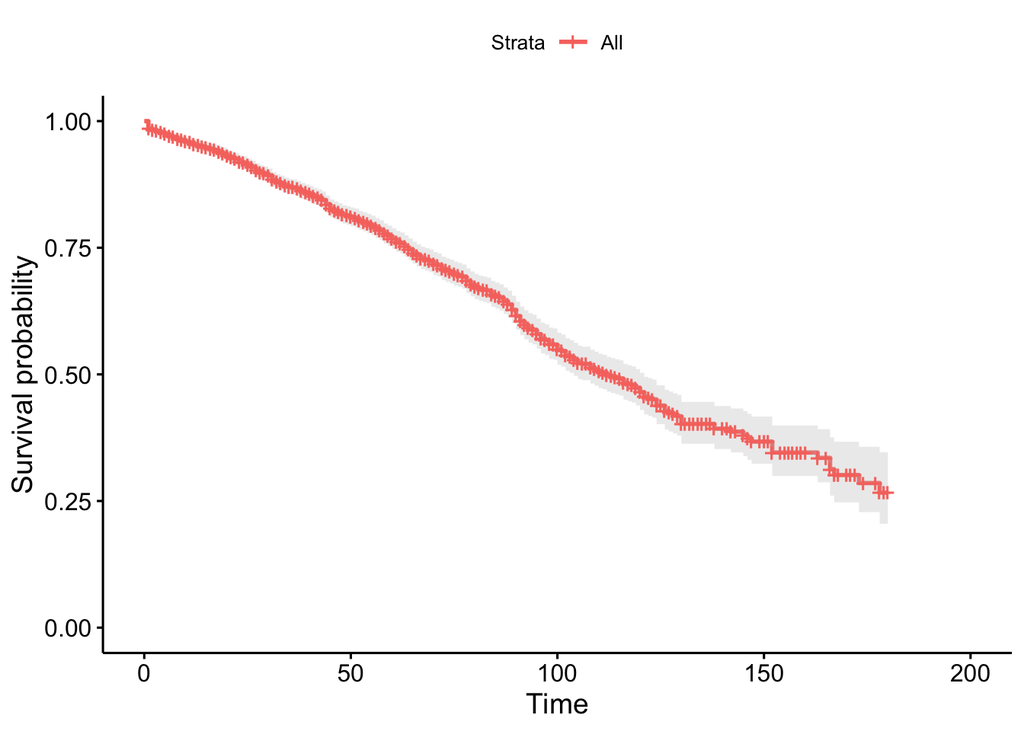

```r
fit1 <- survfit(surv_object ~ 1, data = a_data)
summary(fit1)

ggsurvplot(fit1, data = a_data, pval = TRUE, conf.int = TRUE)
```

```r
ggsave("km_all.pdf", plot = last_plot(), device = "pdf")
```

Next, lets stratify the curve depending on the host types

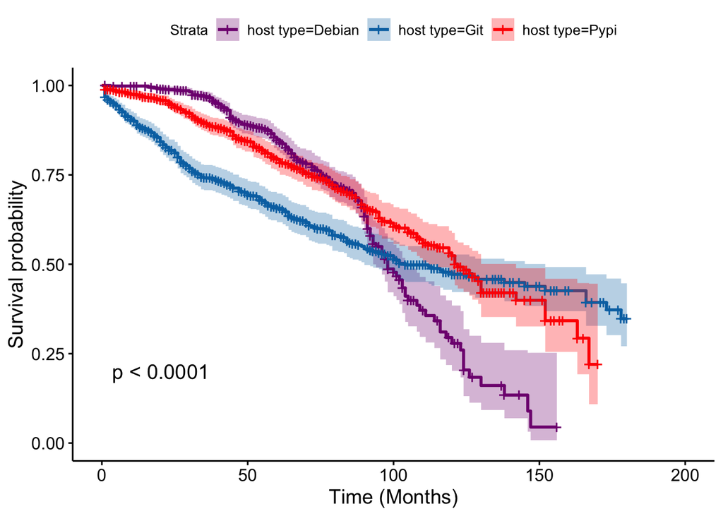

```r
fit3 <- survfit(surv_object ~ host_type, data = a_data)
summary(fit3)
ggsurvplot(fit3, data = a_data, pval = TRUE, conf.int = TRUE, palette=threePalette, xlab="Time (Months)", legend.labs=c("host type=Debian", "host type=Git","host type=Pypi"))
```

```r
ggsave("km_host_type.pdf", plot = last_plot(), device = "pdf")
```

Now. lets stratify the curve depending if the projects had multiple repositories

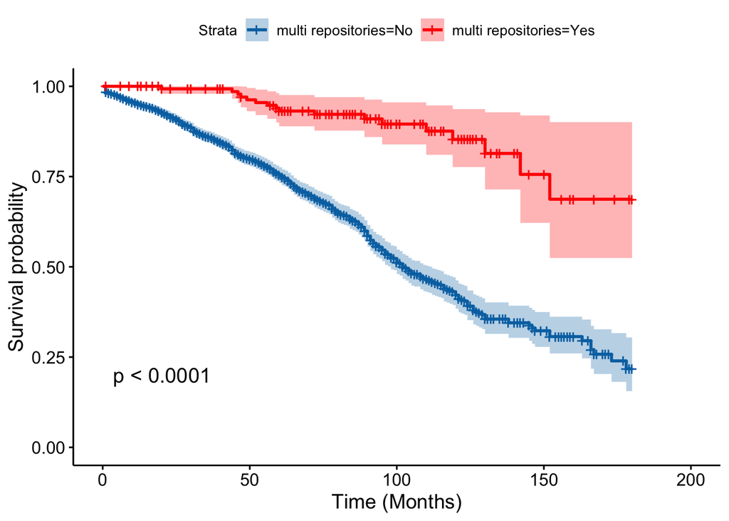

```r
fit4 <- survfit(surv_object ~ multi_repo, data = a_data)
summary(fit4)
ggsurvplot(fit4, data = a_data, pval = TRUE, conf.int = TRUE, xlab="Time (Months)", legend.labs=c("multi repositories=No", "multi repositories=Yes"), palette=twoPalette)
```

```r
ggsave("km_multi_repo.pdf", plot = last_plot(), device = "pdf")
```

at last, lets stratify the curve depending on the author count

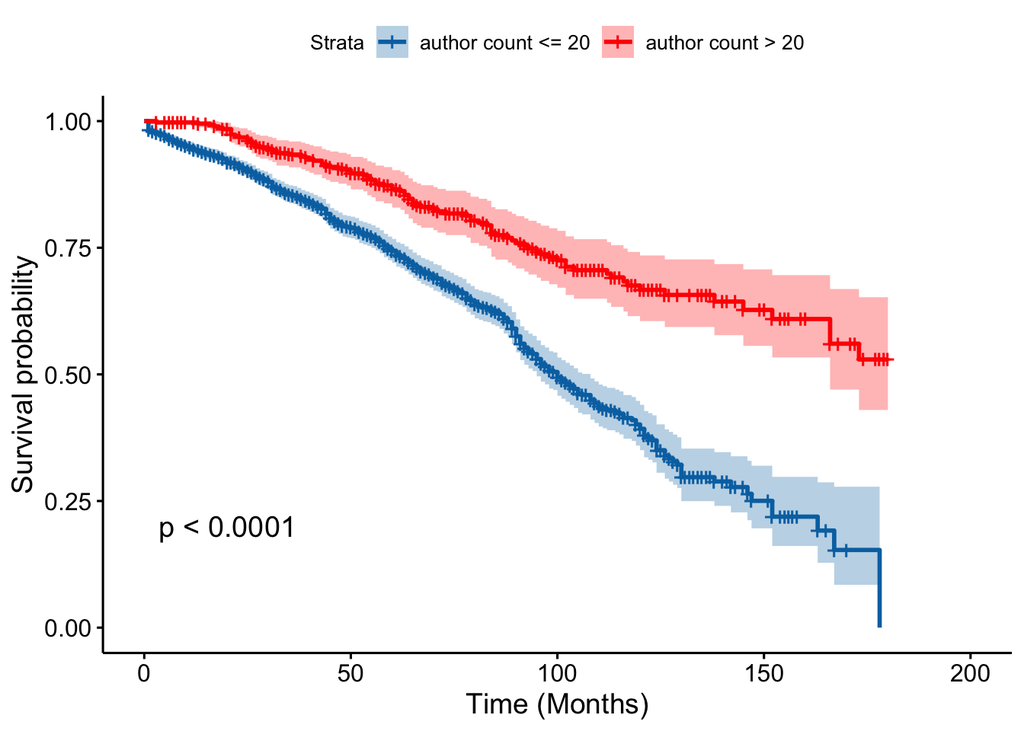

```r
fit5 <- survfit(surv_object ~ high_author_count, data = a_data)
summary(fit5)
ggsurvplot(fit5, data = a_data, pval = TRUE, conf.int = TRUE, legend.labs = c("author count <= 20", "author count > 20"), xlab="Time (Months)", palette=twoPalette)
```

```r
ggsave("km_author_count.pdf", plot = last_plot(), device = "pdf")
```

lets stratify the curve by revision frequency (high is defined as greater than 1 revision a day)

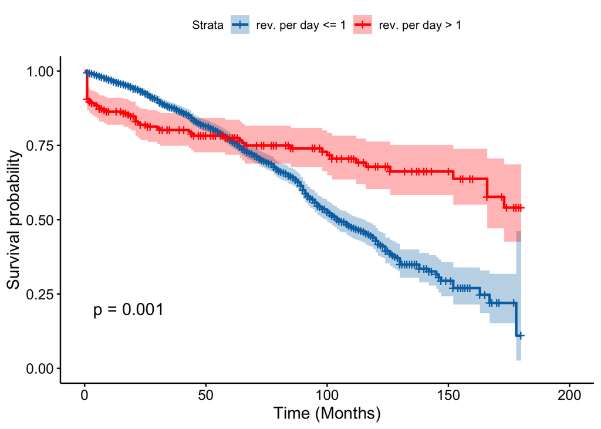

```r
Palette <- c("#D55E00", "#0072B2")
fit6 <- survfit(surv_object ~ high_rev_freq, data = a_data)
summary(fit6)
ggsurvplot(fit6, data = a_data, pval = TRUE, conf.int = TRUE, legend.labs = c("rev. per day <= 1", "rev. per day > 1"), xlab="Time (Months)", palette=twoPalette)
```

```r
ggsave("km_rev_freq.pdf", plot = last_plot(), device = "pdf")
```

# Fit a Cox proportional hazards model

hazard function h(t). It describes the probability of an event or its hazard if the subject survived up to that particular time point (t). It measures the instantaneous risk of death. We need the hazard function to consider covariates when we compare survival of the projects. cox proportional hazards models allow ua to include covariates. We can build Cox proportional hazards models using the coxph function and visualize them using the ggforest.

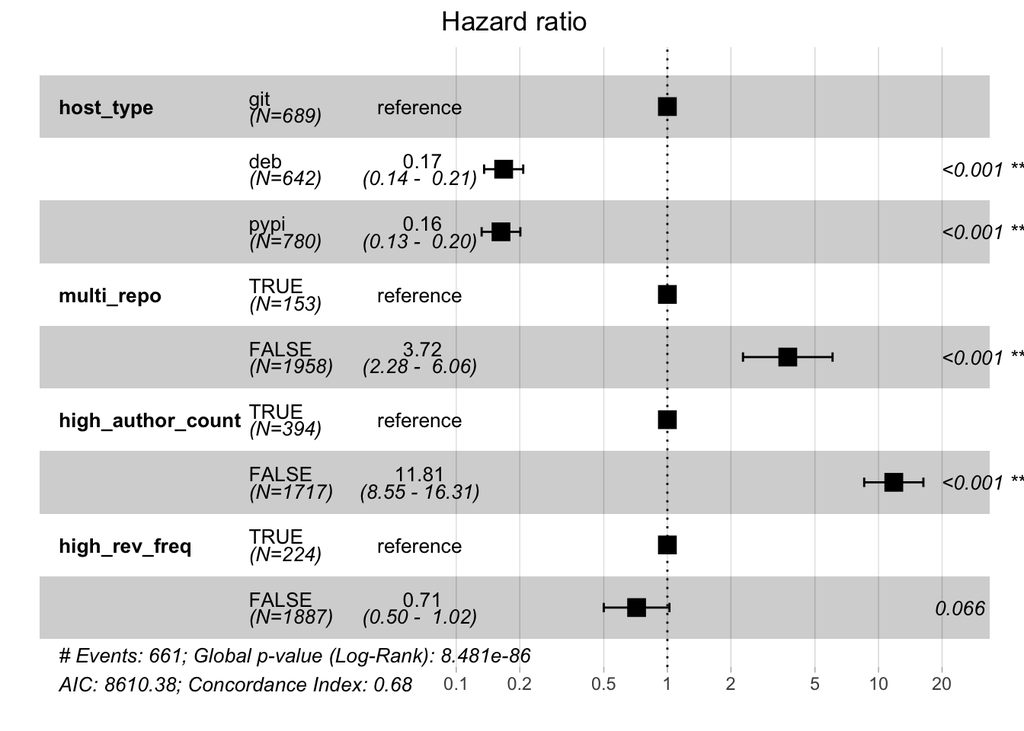

```r
a_data$high_rev_freq = as.factor(a_data$high_rev_freq)
a_data$high_author_count = as.factor(a_data$high_author_count)
a_data$multi_repo = as.factor(a_data$multi_repo)

a_data$multi_repo = relevel(a_data$multi_repo, ref = "TRUE")
a_data$high_author_count = relevel(a_data$high_author_count, ref = "TRUE")
a_data$host_type = relevel(a_data$host_type, ref = "git")
a_data$high_rev_freq = relevel(a_data$high_rev_freq, ref = "TRUE")

fit.coxph <- coxph(surv_object ~ host_type + multi_repo + high_author_count + high_rev_freq, data = a_data)

ggforest(fit.coxph, data = a_data, fontsize=0.9)
```

```r
ggsave("cox.pdf", plot = last_plot(), device = "pdf")
```

Lets see the results, breifly an HR > 1 indicates an increased risk of death and An HR < 1, on the other hand, indicates a decreased risk.